# Risk Factor Analysis

## Outcome Variable

**Outcome Variable:** y_rate_len

## Predictor Variables

**Intervention Variable:** cleanck

**Adjustment Set:**

- arm
- sex
- W_mage
- meducyrs
- feducyrs
- hhwealth_quart
- W_nrooms
- W_nhh
- W_nchldlt5
- trth2o
- impfloor
- delta_meducyrs
- delta_feducyrs
- delta_hhwealth_quart
- delta_W_nrooms
- delta_W_nhh
- delta_W_nchldlt5
- delta_trth2o
- delta_impfloor

## Stratifying Variables

The analysis was stratified on these variable(s):

- agecat
- studyid
- country

## Data Summary

| agecat | studyid | country | cleanck | n_cell | n | outcome_variable |
| --- | --- | --- | --- | --- | --- | --- |
| 0-3 months | ki0047075b-MAL-ED | PERU | 1 | 1 | 1 | y_rate_len |
| 0-3 months | ki0047075b-MAL-ED | PERU | 0 | 0 | 1 | y_rate_len |
| 0-3 months | ki0047075b-MAL-ED | SOUTH AFRICA | 1 | 1 | 2 | y_rate_len |
| 0-3 months | ki0047075b-MAL-ED | SOUTH AFRICA | 0 | 1 | 2 | y_rate_len |
| 0-3 months | ki1000108-CMC-V-BCS-2002 | INDIA | 1 | 40 | 88 | y_rate_len |
| 0-3 months | ki1000108-CMC-V-BCS-2002 | INDIA | 0 | 48 | 88 | y_rate_len |
| 0-3 months | ki1000108-IRC | INDIA | 1 | 212 | 369 | y_rate_len |
| 0-3 months | ki1000108-IRC | INDIA | 0 | 157 | 369 | y_rate_len |
| 0-3 months | ki1017093b-PROVIDE | BANGLADESH | 1 | 529 | 640 | y_rate_len |
| 0-3 months | ki1017093b-PROVIDE | BANGLADESH | 0 | 111 | 640 | y_rate_len |
| 0-3 months | ki1017093c-NIH-Crypto | BANGLADESH | 1 | 334 | 547 | y_rate_len |
| 0-3 months | ki1017093c-NIH-Crypto | BANGLADESH | 0 | 213 | 547 | y_rate_len |
| 0-3 months | ki1113344-GMS-Nepal | NEPAL | 1 | 6 | 460 | y_rate_len |
| 0-3 months | ki1113344-GMS-Nepal | NEPAL | 0 | 454 | 460 | y_rate_len |
| 3-6 months | ki0047075b-MAL-ED | SOUTH AFRICA | 1 | 1 | 1 | y_rate_len |
| 3-6 months | ki0047075b-MAL-ED | SOUTH AFRICA | 0 | 0 | 1 | y_rate_len |
| 3-6 months | ki1000108-CMC-V-BCS-2002 | INDIA | 1 | 133 | 307 | y_rate_len |
| 3-6 months | ki1000108-CMC-V-BCS-2002 | INDIA | 0 | 174 | 307 | y_rate_len |
| 3-6 months | ki1000108-IRC | INDIA | 1 | 224 | 390 | y_rate_len |
| 3-6 months | ki1000108-IRC | INDIA | 0 | 166 | 390 | y_rate_len |
| 3-6 months | ki1017093b-PROVIDE | BANGLADESH | 1 | 492 | 598 | y_rate_len |
| 3-6 months | ki1017093b-PROVIDE | BANGLADESH | 0 | 106 | 598 | y_rate_len |
| 3-6 months | ki1017093c-NIH-Crypto | BANGLADESH | 1 | 315 | 527 | y_rate_len |
| 3-6 months | ki1017093c-NIH-Crypto | BANGLADESH | 0 | 212 | 527 | y_rate_len |
| 3-6 months | ki1113344-GMS-Nepal | NEPAL | 1 | 6 | 424 | y_rate_len |
| 3-6 months | ki1113344-GMS-Nepal | NEPAL | 0 | 418 | 424 | y_rate_len |
| 6-9 months | ki0047075b-MAL-ED | SOUTH AFRICA | 1 | 1 | 1 | y_rate_len |
| 6-9 months | ki0047075b-MAL-ED | SOUTH AFRICA | 0 | 0 | 1 | y_rate_len |
| 6-9 months | ki1000108-CMC-V-BCS-2002 | INDIA | 1 | 136 | 313 | y_rate_len |
| 6-9 months | ki1000108-CMC-V-BCS-2002 | INDIA | 0 | 177 | 313 | y_rate_len |

[output cut: 68 more lines]

The following strata were considered:

- agecat: 0-3 months, studyid: ki0047075b-MAL-ED, country: PERU
- agecat: 0-3 months, studyid: ki0047075b-MAL-ED, country: SOUTH AFRICA
- agecat: 0-3 months, studyid: ki1000108-CMC-V-BCS-2002, country: INDIA
- agecat: 0-3 months, studyid: ki1000108-IRC, country: INDIA
- agecat: 0-3 months, studyid: ki1017093b-PROVIDE, country: BANGLADESH
- agecat: 0-3 months, studyid: ki1017093c-NIH-Crypto, country: BANGLADESH
- agecat: 0-3 months, studyid: ki1113344-GMS-Nepal, country: NEPAL
- agecat: 12-15 months, studyid: ki0047075b-MAL-ED, country: SOUTH AFRICA
- agecat: 12-15 months, studyid: ki1000108-CMC-V-BCS-2002, country: INDIA
- agecat: 12-15 months, studyid: ki1000108-IRC, country: INDIA
- agecat: 12-15 months, studyid: ki1017093b-PROVIDE, country: BANGLADESH
- agecat: 12-15 months, studyid: ki1017093c-NIH-Crypto, country: BANGLADESH
- agecat: 12-15 months, studyid: ki1113344-GMS-Nepal, country: NEPAL
- agecat: 15-18 months, studyid: ki0047075b-MAL-ED, country: SOUTH AFRICA
- agecat: 15-18 months, studyid: ki1000108-CMC-V-BCS-2002, country: INDIA
- agecat: 15-18 months, studyid: ki1000108-IRC, country: INDIA
- agecat: 15-18 months, studyid: ki1017093b-PROVIDE, country: BANGLADESH
- agecat: 15-18 months, studyid: ki1017093c-NIH-Crypto, country: BANGLADESH
- agecat: 15-18 months, studyid: ki1113344-GMS-Nepal, country: NEPAL
- agecat: 18-21 months, studyid: ki0047075b-MAL-ED, country: SOUTH AFRICA
- agecat: 18-21 months, studyid: ki1000108-CMC-V-BCS-2002, country: INDIA
- agecat: 18-21 months, studyid: ki1000108-IRC, country: INDIA
- agecat: 18-21 months, studyid: ki1017093b-PROVIDE, country: BANGLADESH
- agecat: 18-21 months, studyid: ki1017093c-NIH-Crypto, country: BANGLADESH
- agecat: 18-21 months, studyid: ki1113344-GMS-Nepal, country: NEPAL
- agecat: 21-24 months, studyid: ki0047075b-MAL-ED, country: SOUTH AFRICA
- agecat: 21-24 months, studyid: ki1000108-CMC-V-BCS-2002, country: INDIA
- agecat: 21-24 months, studyid: ki1000108-IRC, country: INDIA
- agecat: 21-24 months, studyid: ki1017093b-PROVIDE, country: BANGLADESH
- agecat: 21-24 months, studyid: ki1017093c-NIH-Crypto, country: BANGLADESH
- agecat: 21-24 months, studyid: ki1113344-GMS-Nepal, country: NEPAL
- agecat: 3-6 months, studyid: ki0047075b-MAL-ED, country: SOUTH AFRICA
- agecat: 3-6 months, studyid: ki1000108-CMC-V-BCS-2002, country: INDIA
- agecat: 3-6 months, studyid: ki1000108-IRC, country: INDIA
- agecat: 3-6 months, studyid: ki1017093b-PROVIDE, country: BANGLADESH
- agecat: 3-6 months, studyid: ki1017093c-NIH-Crypto, country: BANGLADESH
- agecat: 3-6 months, studyid: ki1113344-GMS-Nepal, country: NEPAL
- agecat: 6-9 months, studyid: ki0047075b-MAL-ED, country: SOUTH AFRICA
- agecat: 6-9 months, studyid: ki1000108-CMC-V-BCS-2002, country: INDIA
- agecat: 6-9 months, studyid: ki1000108-IRC, country: INDIA
- agecat: 6-9 months, studyid: ki1017093b-PROVIDE, country: BANGLADESH
- agecat: 6-9 months, studyid: ki1017093c-NIH-Crypto, country: BANGLADESH
- agecat: 6-9 months, studyid: ki1113344-GMS-Nepal, country: NEPAL
- agecat: 9-12 months, studyid: ki0047075b-MAL-ED, country: SOUTH AFRICA
- agecat: 9-12 months, studyid: ki1000108-CMC-V-BCS-2002, country: INDIA
- agecat: 9-12 months, studyid: ki1000108-IRC, country: INDIA
- agecat: 9-12 months, studyid: ki1017093b-PROVIDE, country: BANGLADESH
- agecat: 9-12 months, studyid: ki1017093c-NIH-Crypto, country: BANGLADESH
- agecat: 9-12 months, studyid: ki1113344-GMS-Nepal, country: NEPAL

### Dropped Strata

Some strata were dropped due to rare outcomes:

- agecat: 0-3 months, studyid: ki0047075b-MAL-ED, country: PERU
- agecat: 0-3 months, studyid: ki0047075b-MAL-ED, country: SOUTH AFRICA
- agecat: 3-6 months, studyid: ki0047075b-MAL-ED, country: SOUTH AFRICA
- agecat: 6-9 months, studyid: ki0047075b-MAL-ED, country: SOUTH AFRICA
- agecat: 9-12 months, studyid: ki0047075b-MAL-ED, country: SOUTH AFRICA
- agecat: 12-15 months, studyid: ki0047075b-MAL-ED, country: SOUTH AFRICA
- agecat: 15-18 months, studyid: ki0047075b-MAL-ED, country: SOUTH AFRICA
- agecat: 18-21 months, studyid: ki0047075b-MAL-ED, country: SOUTH AFRICA
- agecat: 21-24 months, studyid: ki0047075b-MAL-ED, country: SOUTH AFRICA
- agecat: 21-24 months, studyid: ki1113344-GMS-Nepal, country: NEPAL

## Methods Detail

We’re interested in the causal parameters $E[Y_a]$ for all values of $a \in \mathcal{A}$. These parameters represent the mean outcome if, possibly contrary to fact, we intervened to set all units to have $A=a$. Under the randomization and positivity assumptions, these are identified by the statistical parameters $\psi_a=E_W[E_{Y|A,W}(Y|A=a,W)]$. In addition, we’re interested in the mean of $Y$, $E[Y]$ under no intervention (the observed mean). We will estimate these parameters by using SuperLearner to fit the relevant likelihood factors – $E_{Y|A,W}(Y|A=a,W)$ and $p(A=a|W)$, and then updating our likelihood fit using a joint TMLE.

For unadjusted analyses ($W=\{\}$), initial likelihoods were estimated using Lrnr_glm to estimate the simple $E(Y|A)$ and Lrnr_mean to estimate $p(A)$. For adjusted analyses, a small library containing Lrnr_glmnet, Lrnr_xgboost, and Lrnr_mean was used.

Having estimated these parameters, we will then use the delta method to estimate relative risks and attributable risks relative to a prespecified baseline level of $A$.

# Results Detail

## Results Plots

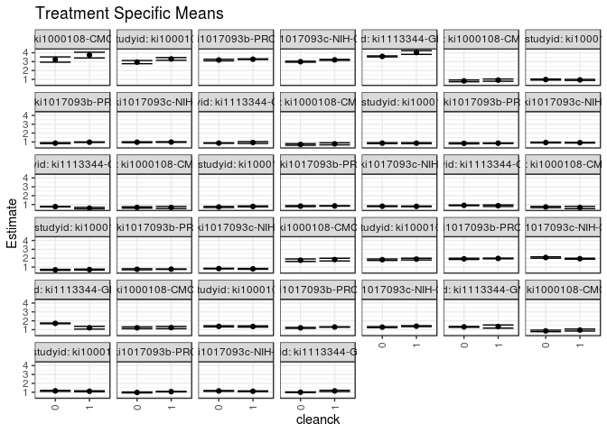

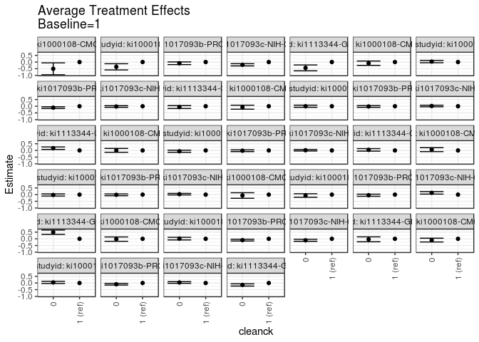

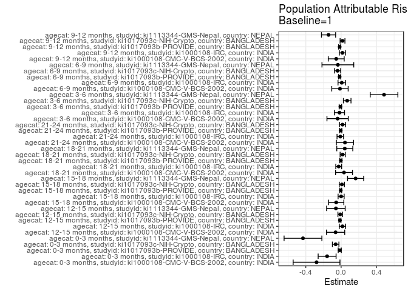

## Results Table

### Parameter: TSM

| agecat | studyid | country | intervention_level | baseline_level | estimate | ci_lower | ci_upper |
| --- | --- | --- | --- | --- | --- | --- | --- |
| 0-3 months | ki1000108-CMC-V-BCS-2002 | INDIA | 1 | NA | 3.7383240 | 3.4168325 | 4.0598155 |
| 0-3 months | ki1000108-CMC-V-BCS-2002 | INDIA | 0 | NA | 3.2340980 | 2.9372544 | 3.5309416 |
| 0-3 months | ki1000108-IRC | INDIA | 1 | NA | 3.3045509 | 3.1566283 | 3.4524735 |
| 0-3 months | ki1000108-IRC | INDIA | 0 | NA | 2.9462888 | 2.7665936 | 3.1259839 |
| 0-3 months | ki1017093b-PROVIDE | BANGLADESH | 1 | NA | 3.2731483 | 3.2327874 | 3.3135092 |
| 0-3 months | ki1017093b-PROVIDE | BANGLADESH | 0 | NA | 3.1828377 | 3.0912738 | 3.2744016 |
| 0-3 months | ki1017093c-NIH-Crypto | BANGLADESH | 1 | NA | 3.1992799 | 3.1393152 | 3.2592445 |
| 0-3 months | ki1017093c-NIH-Crypto | BANGLADESH | 0 | NA | 2.9922689 | 2.9338459 | 3.0506919 |
| 0-3 months | ki1113344-GMS-Nepal | NEPAL | 1 | NA | 4.0267398 | 3.8145010 | 4.2389786 |
| 0-3 months | ki1113344-GMS-Nepal | NEPAL | 0 | NA | 3.5890576 | 3.5338399 | 3.6442753 |
| 3-6 months | ki1000108-CMC-V-BCS-2002 | INDIA | 1 | NA | 1.8436243 | 1.6897699 | 1.9974788 |
| 3-6 months | ki1000108-CMC-V-BCS-2002 | INDIA | 0 | NA | 1.7770374 | 1.6376584 | 1.9164165 |
| 3-6 months | ki1000108-IRC | INDIA | 1 | NA | 1.8994966 | 1.8017877 | 1.9972056 |
| 3-6 months | ki1000108-IRC | INDIA | 0 | NA | 1.8351761 | 1.7506940 | 1.9196582 |
| 3-6 months | ki1017093b-PROVIDE | BANGLADESH | 1 | NA | 1.9740028 | 1.9355909 | 2.0124148 |
| 3-6 months | ki1017093b-PROVIDE | BANGLADESH | 0 | NA | 1.9287620 | 1.8589378 | 1.9985861 |
| 3-6 months | ki1017093c-NIH-Crypto | BANGLADESH | 1 | NA | 1.9439584 | 1.8896057 | 1.9983110 |
| 3-6 months | ki1017093c-NIH-Crypto | BANGLADESH | 0 | NA | 2.0790613 | 2.0042208 | 2.1539019 |
| 3-6 months | ki1113344-GMS-Nepal | NEPAL | 1 | NA | 1.2139650 | 1.0591458 | 1.3687842 |
| 3-6 months | ki1113344-GMS-Nepal | NEPAL | 0 | NA | 1.7068916 | 1.6642904 | 1.7494928 |
| 6-9 months | ki1000108-CMC-V-BCS-2002 | INDIA | 1 | NA | 1.2305454 | 1.1052502 | 1.3558406 |
| 6-9 months | ki1000108-CMC-V-BCS-2002 | INDIA | 0 | NA | 1.2073994 | 1.1050958 | 1.3097029 |
| 6-9 months | ki1000108-IRC | INDIA | 1 | NA | 1.3583813 | 1.2889051 | 1.4278575 |
| 6-9 months | ki1000108-IRC | INDIA | 0 | NA | 1.3718173 | 1.3050848 | 1.4385498 |
| 6-9 months | ki1017093b-PROVIDE | BANGLADESH | 1 | NA | 1.2996070 | 1.2715444 | 1.3276696 |
| 6-9 months | ki1017093b-PROVIDE | BANGLADESH | 0 | NA | 1.2015973 | 1.1437106 | 1.2594839 |
| 6-9 months | ki1017093c-NIH-Crypto | BANGLADESH | 1 | NA | 1.3929493 | 1.3409840 | 1.4449147 |
| 6-9 months | ki1017093c-NIH-Crypto | BANGLADESH | 0 | NA | 1.2826087 | 1.2280193 | 1.3371982 |
| 6-9 months | ki1113344-GMS-Nepal | NEPAL | 1 | NA | 1.3515781 | 1.1725495 | 1.5306067 |
| 6-9 months | ki1113344-GMS-Nepal | NEPAL | 0 | NA | 1.3140376 | 1.2691138 | 1.3589614 |
| 9-12 months | ki1000108-CMC-V-BCS-2002 | INDIA | 1 | NA | 0.9549920 | 0.8446153 | 1.0653687 |
| 9-12 months | ki1000108-CMC-V-BCS-2002 | INDIA | 0 | NA | 0.8580704 | 0.7694981 | 0.9466427 |
| 9-12 months | ki1000108-IRC | INDIA | 1 | NA | 1.1083734 | 1.0529170 | 1.1638299 |
| 9-12 months | ki1000108-IRC | INDIA | 0 | NA | 1.1534252 | 1.0927537 | 1.2140966 |
| 9-12 months | ki1017093b-PROVIDE | BANGLADESH | 1 | NA | 1.0665000 | 1.0359920 | 1.0970079 |
| 9-12 months | ki1017093b-PROVIDE | BANGLADESH | 0 | NA | 0.9749183 | 0.9205535 | 1.0292832 |
| 9-12 months | ki1017093c-NIH-Crypto | BANGLADESH | 1 | NA | 1.1085606 | 1.0670090 | 1.1501121 |
| 9-12 months | ki1017093c-NIH-Crypto | BANGLADESH | 0 | NA | 1.1467886 | 1.1005231 | 1.1930542 |
| 9-12 months | ki1113344-GMS-Nepal | NEPAL | 1 | NA | 1.1461261 | 1.0720811 | 1.2201711 |
| 9-12 months | ki1113344-GMS-Nepal | NEPAL | 0 | NA | 1.0011032 | 0.9653508 | 1.0368557 |
| 12-15 months | ki1000108-CMC-V-BCS-2002 | INDIA | 1 | NA | 0.9161568 | 0.7894691 | 1.0428444 |
| 12-15 months | ki1000108-CMC-V-BCS-2002 | INDIA | 0 | NA | 0.8296788 | 0.7322526 | 0.9271050 |
| 12-15 months | ki1000108-IRC | INDIA | 1 | NA | 0.9423626 | 0.8833797 | 1.0013455 |
| 12-15 months | ki1000108-IRC | INDIA | 0 | NA | 0.9784997 | 0.9148494 | 1.0421500 |
| 12-15 months | ki1017093b-PROVIDE | BANGLADESH | 1 | NA | 0.9730829 | 0.9440271 | 1.0021386 |
| 12-15 months | ki1017093b-PROVIDE | BANGLADESH | 0 | NA | 0.8671979 | 0.8093562 | 0.9250395 |
| 12-15 months | ki1017093c-NIH-Crypto | BANGLADESH | 1 | NA | 0.9900392 | 0.9517372 | 1.0283412 |
| 12-15 months | ki1017093c-NIH-Crypto | BANGLADESH | 0 | NA | 0.9697890 | 0.9217294 | 1.0178486 |
| 12-15 months | ki1113344-GMS-Nepal | NEPAL | 1 | NA | 0.9345104 | 0.8314399 | 1.0375809 |
| 12-15 months | ki1113344-GMS-Nepal | NEPAL | 0 | NA | 0.8742379 | 0.8427187 | 0.9057571 |
| 15-18 months | ki1000108-CMC-V-BCS-2002 | INDIA | 1 | NA | 0.7898659 | 0.6741081 | 0.9056237 |
| 15-18 months | ki1000108-CMC-V-BCS-2002 | INDIA | 0 | NA | 0.7183330 | 0.6291741 | 0.8074919 |
| 15-18 months | ki1000108-IRC | INDIA | 1 | NA | 0.8634919 | 0.8042415 | 0.9227423 |
| 15-18 months | ki1000108-IRC | INDIA | 0 | NA | 0.8635015 | 0.8104769 | 0.9165260 |
| 15-18 months | ki1017093b-PROVIDE | BANGLADESH | 1 | NA | 0.8603691 | 0.8337616 | 0.8869766 |
| 15-18 months | ki1017093b-PROVIDE | BANGLADESH | 0 | NA | 0.8440780 | 0.7852140 | 0.9029420 |
| 15-18 months | ki1017093c-NIH-Crypto | BANGLADESH | 1 | NA | 0.9156000 | 0.8757143 | 0.9554858 |
| 15-18 months | ki1017093c-NIH-Crypto | BANGLADESH | 0 | NA | 0.9321176 | 0.8888969 | 0.9753383 |
| 15-18 months | ki1113344-GMS-Nepal | NEPAL | 1 | NA | 0.5938125 | 0.5084972 | 0.6791279 |
| 15-18 months | ki1113344-GMS-Nepal | NEPAL | 0 | NA | 0.7611989 | 0.7229049 | 0.7994929 |
| 18-21 months | ki1000108-CMC-V-BCS-2002 | INDIA | 1 | NA | 0.6672673 | 0.5484160 | 0.7861185 |
| 18-21 months | ki1000108-CMC-V-BCS-2002 | INDIA | 0 | NA | 0.6728969 | 0.5941413 | 0.7516525 |
| 18-21 months | ki1000108-IRC | INDIA | 1 | NA | 0.7840579 | 0.7320719 | 0.8360438 |
| 18-21 months | ki1000108-IRC | INDIA | 0 | NA | 0.7223436 | 0.6641295 | 0.7805577 |
| 18-21 months | ki1017093b-PROVIDE | BANGLADESH | 1 | NA | 0.8422167 | 0.8162779 | 0.8681555 |
| 18-21 months | ki1017093b-PROVIDE | BANGLADESH | 0 | NA | 0.8212446 | 0.7611346 | 0.8813546 |
| 18-21 months | ki1017093c-NIH-Crypto | BANGLADESH | 1 | NA | 0.7920743 | 0.7534971 | 0.8306515 |
| 18-21 months | ki1017093c-NIH-Crypto | BANGLADESH | 0 | NA | 0.8088463 | 0.7681925 | 0.8495002 |
| 18-21 months | ki1113344-GMS-Nepal | NEPAL | 1 | NA | 0.8652948 | 0.7802558 | 0.9503338 |
| 18-21 months | ki1113344-GMS-Nepal | NEPAL | 0 | NA | 0.9075162 | 0.8701345 | 0.9448979 |
| 21-24 months | ki1000108-CMC-V-BCS-2002 | INDIA | 1 | NA | 0.6634578 | 0.5358588 | 0.7910569 |
| 21-24 months | ki1000108-CMC-V-BCS-2002 | INDIA | 0 | NA | 0.7225583 | 0.6514642 | 0.7936523 |
| 21-24 months | ki1000108-IRC | INDIA | 1 | NA | 0.7161386 | 0.6600336 | 0.7722436 |
| 21-24 months | ki1000108-IRC | INDIA | 0 | NA | 0.6889741 | 0.6301555 | 0.7477928 |
| 21-24 months | ki1017093b-PROVIDE | BANGLADESH | 1 | NA | 0.7676296 | 0.7399284 | 0.7953309 |
| 21-24 months | ki1017093b-PROVIDE | BANGLADESH | 0 | NA | 0.7525020 | 0.6903044 | 0.8146995 |
| 21-24 months | ki1017093c-NIH-Crypto | BANGLADESH | 1 | NA | 0.7988321 | 0.7527716 | 0.8448925 |
| 21-24 months | ki1017093c-NIH-Crypto | BANGLADESH | 0 | NA | 0.8312215 | 0.7942715 | 0.8681715 |

### Parameter: E(Y)

| agecat | studyid | country | intervention_level | baseline_level | estimate | ci_lower | ci_upper |
| --- | --- | --- | --- | --- | --- | --- | --- |
| 0-3 months | ki1000108-CMC-V-BCS-2002 | INDIA | NA | NA | 3.4601875 | 3.2440906 | 3.6762845 |
| 0-3 months | ki1000108-IRC | INDIA | NA | NA | 3.1459932 | 3.0340880 | 3.2578984 |
| 0-3 months | ki1017093b-PROVIDE | BANGLADESH | NA | NA | 3.2576810 | 3.2206777 | 3.2946843 |
| 0-3 months | ki1017093c-NIH-Crypto | BANGLADESH | NA | NA | 3.1373236 | 3.0972506 | 3.1773966 |
| 0-3 months | ki1113344-GMS-Nepal | NEPAL | NA | NA | 3.5947665 | 3.5404780 | 3.6490550 |
| 3-6 months | ki1000108-CMC-V-BCS-2002 | INDIA | NA | NA | 1.8037880 | 1.7029866 | 1.9045894 |
| 3-6 months | ki1000108-IRC | INDIA | NA | NA | 1.8807708 | 1.8161067 | 1.9454349 |
| 3-6 months | ki1017093b-PROVIDE | BANGLADESH | NA | NA | 1.9657457 | 1.9318660 | 1.9996254 |
| 3-6 months | ki1017093c-NIH-Crypto | BANGLADESH | NA | NA | 2.0125524 | 1.9699507 | 2.0551541 |
| 3-6 months | ki1113344-GMS-Nepal | NEPAL | NA | NA | 1.6999162 | 1.6578328 | 1.7419997 |
| 6-9 months | ki1000108-CMC-V-BCS-2002 | INDIA | NA | NA | 1.2173381 | 1.1398153 | 1.2948610 |
| 6-9 months | ki1000108-IRC | INDIA | NA | NA | 1.3656516 | 1.3178011 | 1.4135021 |
| 6-9 months | ki1017093b-PROVIDE | BANGLADESH | NA | NA | 1.2824185 | 1.2571827 | 1.3076542 |
| 6-9 months | ki1017093c-NIH-Crypto | BANGLADESH | NA | NA | 1.3527759 | 1.3181375 | 1.3874142 |
| 6-9 months | ki1113344-GMS-Nepal | NEPAL | NA | NA | 1.3147312 | 1.2706998 | 1.3587625 |
| 9-12 months | ki1000108-CMC-V-BCS-2002 | INDIA | NA | NA | 0.8995224 | 0.8316661 | 0.9673787 |
| 9-12 months | ki1000108-IRC | INDIA | NA | NA | 1.1229343 | 1.0831083 | 1.1627603 |
| 9-12 months | ki1017093b-PROVIDE | BANGLADESH | NA | NA | 1.0499750 | 1.0230130 | 1.0769370 |
| 9-12 months | ki1017093c-NIH-Crypto | BANGLADESH | NA | NA | 1.1243367 | 1.0942919 | 1.1543816 |
| 9-12 months | ki1113344-GMS-Nepal | NEPAL | NA | NA | 1.0038395 | 0.9688811 | 1.0387978 |
| 12-15 months | ki1000108-CMC-V-BCS-2002 | INDIA | NA | NA | 0.8533724 | 0.7837188 | 0.9230260 |
| 12-15 months | ki1000108-IRC | INDIA | NA | NA | 0.9574323 | 0.9150475 | 0.9998172 |
| 12-15 months | ki1017093b-PROVIDE | BANGLADESH | NA | NA | 0.9597501 | 0.9335899 | 0.9859102 |
| 12-15 months | ki1017093c-NIH-Crypto | BANGLADESH | NA | NA | 0.9797232 | 0.9513105 | 1.0081359 |
| 12-15 months | ki1113344-GMS-Nepal | NEPAL | NA | NA | 0.8753778 | 0.8445288 | 0.9062268 |
| 15-18 months | ki1000108-CMC-V-BCS-2002 | INDIA | NA | NA | 0.7339135 | 0.6710399 | 0.7967871 |
| 15-18 months | ki1000108-IRC | INDIA | NA | NA | 0.8635602 | 0.8235728 | 0.9035477 |
| 15-18 months | ki1017093b-PROVIDE | BANGLADESH | NA | NA | 0.8560998 | 0.8320145 | 0.8801852 |
| 15-18 months | ki1017093c-NIH-Crypto | BANGLADESH | NA | NA | 0.9239169 | 0.8976277 | 0.9502061 |
| 15-18 months | ki1113344-GMS-Nepal | NEPAL | NA | NA | 0.7581134 | 0.7206558 | 0.7955710 |
| 18-21 months | ki1000108-CMC-V-BCS-2002 | INDIA | NA | NA | 0.6999920 | 0.6362204 | 0.7637635 |
| 18-21 months | ki1000108-IRC | INDIA | NA | NA | 0.7567726 | 0.7181843 | 0.7953609 |
| 18-21 months | ki1017093b-PROVIDE | BANGLADESH | NA | NA | 0.8393377 | 0.8153485 | 0.8633269 |
| 18-21 months | ki1017093c-NIH-Crypto | BANGLADESH | NA | NA | 0.8098412 | 0.7838581 | 0.8358244 |
| 18-21 months | ki1113344-GMS-Nepal | NEPAL | NA | NA | 0.9067882 | 0.8702752 | 0.9433012 |
| 21-24 months | ki1000108-CMC-V-BCS-2002 | INDIA | NA | NA | 0.7068472 | 0.6454809 | 0.7682134 |
| 21-24 months | ki1000108-IRC | INDIA | NA | NA | 0.7066493 | 0.6649098 | 0.7483888 |
| 21-24 months | ki1017093b-PROVIDE | BANGLADESH | NA | NA | 0.7631391 | 0.7377453 | 0.7885328 |
| 21-24 months | ki1017093c-NIH-Crypto | BANGLADESH | NA | NA | 0.8147508 | 0.7880257 | 0.8414758 |

### Parameter: ATE

| agecat | studyid | country | intervention_level | baseline_level | estimate | ci_lower | ci_upper |
| --- | --- | --- | --- | --- | --- | --- | --- |
| 0-3 months | ki1000108-CMC-V-BCS-2002 | INDIA | 1 | 1 | 0.0000000 | 0.0000000 | 0.0000000 |
| 0-3 months | ki1000108-CMC-V-BCS-2002 | INDIA | 0 | 1 | -0.5042260 | -0.9469869 | -0.0614651 |
| 0-3 months | ki1000108-IRC | INDIA | 1 | 1 | 0.0000000 | 0.0000000 | 0.0000000 |
| 0-3 months | ki1000108-IRC | INDIA | 0 | 1 | -0.3582621 | -0.5911138 | -0.1254105 |
| 0-3 months | ki1017093b-PROVIDE | BANGLADESH | 1 | 1 | 0.0000000 | 0.0000000 | 0.0000000 |
| 0-3 months | ki1017093b-PROVIDE | BANGLADESH | 0 | 1 | -0.0903106 | -0.1904091 | 0.0097879 |
| 0-3 months | ki1017093c-NIH-Crypto | BANGLADESH | 1 | 1 | 0.0000000 | 0.0000000 | 0.0000000 |
| 0-3 months | ki1017093c-NIH-Crypto | BANGLADESH | 0 | 1 | -0.2070109 | -0.2912540 | -0.1227679 |
| 0-3 months | ki1113344-GMS-Nepal | NEPAL | 1 | 1 | 0.0000000 | 0.0000000 | 0.0000000 |
| 0-3 months | ki1113344-GMS-Nepal | NEPAL | 0 | 1 | -0.4376822 | -0.6569863 | -0.2183781 |
| 3-6 months | ki1000108-CMC-V-BCS-2002 | INDIA | 1 | 1 | 0.0000000 | 0.0000000 | 0.0000000 |
| 3-6 months | ki1000108-CMC-V-BCS-2002 | INDIA | 0 | 1 | -0.0665869 | -0.2745676 | 0.1413939 |
| 3-6 months | ki1000108-IRC | INDIA | 1 | 1 | 0.0000000 | 0.0000000 | 0.0000000 |
| 3-6 months | ki1000108-IRC | INDIA | 0 | 1 | -0.0643205 | -0.1941825 | 0.0655414 |
| 3-6 months | ki1017093b-PROVIDE | BANGLADESH | 1 | 1 | 0.0000000 | 0.0000000 | 0.0000000 |
| 3-6 months | ki1017093b-PROVIDE | BANGLADESH | 0 | 1 | -0.0452409 | -0.1249208 | 0.0344391 |
| 3-6 months | ki1017093c-NIH-Crypto | BANGLADESH | 1 | 1 | 0.0000000 | 0.0000000 | 0.0000000 |
| 3-6 months | ki1017093c-NIH-Crypto | BANGLADESH | 0 | 1 | 0.1351030 | 0.0425596 | 0.2276464 |
| 3-6 months | ki1113344-GMS-Nepal | NEPAL | 1 | 1 | 0.0000000 | 0.0000000 | 0.0000000 |
| 3-6 months | ki1113344-GMS-Nepal | NEPAL | 0 | 1 | 0.4929266 | 0.3323531 | 0.6535001 |
| 6-9 months | ki1000108-CMC-V-BCS-2002 | INDIA | 1 | 1 | 0.0000000 | 0.0000000 | 0.0000000 |
| 6-9 months | ki1000108-CMC-V-BCS-2002 | INDIA | 0 | 1 | -0.0231460 | -0.1845639 | 0.1382718 |
| 6-9 months | ki1000108-IRC | INDIA | 1 | 1 | 0.0000000 | 0.0000000 | 0.0000000 |
| 6-9 months | ki1000108-IRC | INDIA | 0 | 1 | 0.0134360 | -0.0841214 | 0.1109934 |
| 6-9 months | ki1017093b-PROVIDE | BANGLADESH | 1 | 1 | 0.0000000 | 0.0000000 | 0.0000000 |
| 6-9 months | ki1017093b-PROVIDE | BANGLADESH | 0 | 1 | -0.0980097 | -0.1626205 | -0.0333989 |
| 6-9 months | ki1017093c-NIH-Crypto | BANGLADESH | 1 | 1 | 0.0000000 | 0.0000000 | 0.0000000 |
| 6-9 months | ki1017093c-NIH-Crypto | BANGLADESH | 0 | 1 | -0.1103406 | -0.1858642 | -0.0348170 |
| 6-9 months | ki1113344-GMS-Nepal | NEPAL | 1 | 1 | 0.0000000 | 0.0000000 | 0.0000000 |
| 6-9 months | ki1113344-GMS-Nepal | NEPAL | 0 | 1 | -0.0375405 | -0.2221194 | 0.1470385 |
| 9-12 months | ki1000108-CMC-V-BCS-2002 | INDIA | 1 | 1 | 0.0000000 | 0.0000000 | 0.0000000 |
| 9-12 months | ki1000108-CMC-V-BCS-2002 | INDIA | 0 | 1 | -0.0969216 | -0.2388830 | 0.0450398 |
| 9-12 months | ki1000108-IRC | INDIA | 1 | 1 | 0.0000000 | 0.0000000 | 0.0000000 |
| 9-12 months | ki1000108-IRC | INDIA | 0 | 1 | 0.0450517 | -0.0369758 | 0.1270792 |
| 9-12 months | ki1017093b-PROVIDE | BANGLADESH | 1 | 1 | 0.0000000 | 0.0000000 | 0.0000000 |
| 9-12 months | ki1017093b-PROVIDE | BANGLADESH | 0 | 1 | -0.0915816 | -0.1539609 | -0.0292024 |
| 9-12 months | ki1017093c-NIH-Crypto | BANGLADESH | 1 | 1 | 0.0000000 | 0.0000000 | 0.0000000 |
| 9-12 months | ki1017093c-NIH-Crypto | BANGLADESH | 0 | 1 | 0.0382281 | -0.0238723 | 0.1003284 |
| 9-12 months | ki1113344-GMS-Nepal | NEPAL | 1 | 1 | 0.0000000 | 0.0000000 | 0.0000000 |
| 9-12 months | ki1113344-GMS-Nepal | NEPAL | 0 | 1 | -0.1450229 | -0.2272476 | -0.0627982 |
| 12-15 months | ki1000108-CMC-V-BCS-2002 | INDIA | 1 | 1 | 0.0000000 | 0.0000000 | 0.0000000 |
| 12-15 months | ki1000108-CMC-V-BCS-2002 | INDIA | 0 | 1 | -0.0864780 | -0.2483433 | 0.0753873 |
| 12-15 months | ki1000108-IRC | INDIA | 1 | 1 | 0.0000000 | 0.0000000 | 0.0000000 |
| 12-15 months | ki1000108-IRC | INDIA | 0 | 1 | 0.0361371 | -0.0505354 | 0.1228095 |
| 12-15 months | ki1017093b-PROVIDE | BANGLADESH | 1 | 1 | 0.0000000 | 0.0000000 | 0.0000000 |
| 12-15 months | ki1017093b-PROVIDE | BANGLADESH | 0 | 1 | -0.1058850 | -0.1707752 | -0.0409948 |
| 12-15 months | ki1017093c-NIH-Crypto | BANGLADESH | 1 | 1 | 0.0000000 | 0.0000000 | 0.0000000 |
| 12-15 months | ki1017093c-NIH-Crypto | BANGLADESH | 0 | 1 | -0.0202502 | -0.0815796 | 0.0410792 |
| 12-15 months | ki1113344-GMS-Nepal | NEPAL | 1 | 1 | 0.0000000 | 0.0000000 | 0.0000000 |
| 12-15 months | ki1113344-GMS-Nepal | NEPAL | 0 | 1 | -0.0602725 | -0.1680547 | 0.0475096 |
| 15-18 months | ki1000108-CMC-V-BCS-2002 | INDIA | 1 | 1 | 0.0000000 | 0.0000000 | 0.0000000 |
| 15-18 months | ki1000108-CMC-V-BCS-2002 | INDIA | 0 | 1 | -0.0715329 | -0.2203578 | 0.0772920 |
| 15-18 months | ki1000108-IRC | INDIA | 1 | 1 | 0.0000000 | 0.0000000 | 0.0000000 |
| 15-18 months | ki1000108-IRC | INDIA | 0 | 1 | 0.0000096 | -0.0799747 | 0.0799938 |
| 15-18 months | ki1017093b-PROVIDE | BANGLADESH | 1 | 1 | 0.0000000 | 0.0000000 | 0.0000000 |
| 15-18 months | ki1017093b-PROVIDE | BANGLADESH | 0 | 1 | -0.0162911 | -0.0811109 | 0.0485286 |
| 15-18 months | ki1017093c-NIH-Crypto | BANGLADESH | 1 | 1 | 0.0000000 | 0.0000000 | 0.0000000 |
| 15-18 months | ki1017093c-NIH-Crypto | BANGLADESH | 0 | 1 | 0.0165176 | -0.0425903 | 0.0756256 |
| 15-18 months | ki1113344-GMS-Nepal | NEPAL | 1 | 1 | 0.0000000 | 0.0000000 | 0.0000000 |
| 15-18 months | ki1113344-GMS-Nepal | NEPAL | 0 | 1 | 0.1673863 | 0.0738709 | 0.2609018 |
| 18-21 months | ki1000108-CMC-V-BCS-2002 | INDIA | 1 | 1 | 0.0000000 | 0.0000000 | 0.0000000 |
| 18-21 months | ki1000108-CMC-V-BCS-2002 | INDIA | 0 | 1 | 0.0056296 | -0.1375815 | 0.1488407 |
| 18-21 months | ki1000108-IRC | INDIA | 1 | 1 | 0.0000000 | 0.0000000 | 0.0000000 |
| 18-21 months | ki1000108-IRC | INDIA | 0 | 1 | -0.0617143 | -0.1402344 | 0.0168059 |
| 18-21 months | ki1017093b-PROVIDE | BANGLADESH | 1 | 1 | 0.0000000 | 0.0000000 | 0.0000000 |
| 18-21 months | ki1017093b-PROVIDE | BANGLADESH | 0 | 1 | -0.0209721 | -0.0863384 | 0.0443942 |
| 18-21 months | ki1017093c-NIH-Crypto | BANGLADESH | 1 | 1 | 0.0000000 | 0.0000000 | 0.0000000 |
| 18-21 months | ki1017093c-NIH-Crypto | BANGLADESH | 0 | 1 | 0.0167721 | -0.0394298 | 0.0729739 |
| 18-21 months | ki1113344-GMS-Nepal | NEPAL | 1 | 1 | 0.0000000 | 0.0000000 | 0.0000000 |
| 18-21 months | ki1113344-GMS-Nepal | NEPAL | 0 | 1 | 0.0422214 | -0.0506711 | 0.1351139 |
| 21-24 months | ki1000108-CMC-V-BCS-2002 | INDIA | 1 | 1 | 0.0000000 | 0.0000000 | 0.0000000 |
| 21-24 months | ki1000108-CMC-V-BCS-2002 | INDIA | 0 | 1 | 0.0591004 | -0.0869979 | 0.2051987 |
| 21-24 months | ki1000108-IRC | INDIA | 1 | 1 | 0.0000000 | 0.0000000 | 0.0000000 |
| 21-24 months | ki1000108-IRC | INDIA | 0 | 1 | -0.0271645 | -0.1087516 | 0.0544227 |
| 21-24 months | ki1017093b-PROVIDE | BANGLADESH | 1 | 1 | 0.0000000 | 0.0000000 | 0.0000000 |
| 21-24 months | ki1017093b-PROVIDE | BANGLADESH | 0 | 1 | -0.0151277 | -0.0832502 | 0.0529948 |
| 21-24 months | ki1017093c-NIH-Crypto | BANGLADESH | 1 | 1 | 0.0000000 | 0.0000000 | 0.0000000 |
| 21-24 months | ki1017093c-NIH-Crypto | BANGLADESH | 0 | 1 | 0.0323894 | -0.0266786 | 0.0914575 |

### Parameter: PAR

| agecat | studyid | country | intervention_level | baseline_level | estimate | ci_lower | ci_upper |
| --- | --- | --- | --- | --- | --- | --- | --- |
| 0-3 months | ki1000108-CMC-V-BCS-2002 | INDIA | 1 | NA | -0.2781364 | -0.5431705 | -0.0131023 |
| 0-3 months | ki1000108-IRC | INDIA | 1 | NA | -0.1585577 | -0.2600481 | -0.0570672 |
| 0-3 months | ki1017093b-PROVIDE | BANGLADESH | 1 | NA | -0.0154673 | -0.0329802 | 0.0020457 |
| 0-3 months | ki1017093c-NIH-Crypto | BANGLADESH | 1 | NA | -0.0619562 | -0.0988459 | -0.0250666 |
| 0-3 months | ki1113344-GMS-Nepal | NEPAL | 1 | NA | -0.4319733 | -0.6458430 | -0.2181035 |
| 3-6 months | ki1000108-CMC-V-BCS-2002 | INDIA | 1 | NA | -0.0398363 | -0.1604080 | 0.0807354 |
| 3-6 months | ki1000108-IRC | INDIA | 1 | NA | -0.0187258 | -0.0761385 | 0.0386869 |
| 3-6 months | ki1017093b-PROVIDE | BANGLADESH | 1 | NA | -0.0082571 | -0.0223249 | 0.0058107 |
| 3-6 months | ki1017093c-NIH-Crypto | BANGLADESH | 1 | NA | 0.0685941 | 0.0254456 | 0.1117426 |
| 3-6 months | ki1113344-GMS-Nepal | NEPAL | 1 | NA | 0.4859512 | 0.3292938 | 0.6426086 |
| 6-9 months | ki1000108-CMC-V-BCS-2002 | INDIA | 1 | NA | -0.0132072 | -0.1061202 | 0.0797058 |
| 6-9 months | ki1000108-IRC | INDIA | 1 | NA | 0.0072703 | -0.0350983 | 0.0496389 |
| 6-9 months | ki1017093b-PROVIDE | BANGLADESH | 1 | NA | -0.0171885 | -0.0294395 | -0.0049375 |
| 6-9 months | ki1017093c-NIH-Crypto | BANGLADESH | 1 | NA | -0.0401735 | -0.0748433 | -0.0055036 |
| 6-9 months | ki1113344-GMS-Nepal | NEPAL | 1 | NA | -0.0368469 | -0.2168120 | 0.1431182 |
| 9-12 months | ki1000108-CMC-V-BCS-2002 | INDIA | 1 | NA | -0.0554696 | -0.1458022 | 0.0348630 |
| 9-12 months | ki1000108-IRC | INDIA | 1 | NA | 0.0145608 | -0.0203068 | 0.0494284 |
| 9-12 months | ki1017093b-PROVIDE | BANGLADESH | 1 | NA | -0.0165250 | -0.0280229 | -0.0050270 |
| 9-12 months | ki1017093c-NIH-Crypto | BANGLADESH | 1 | NA | 0.0157761 | -0.0115285 | 0.0430808 |
| 9-12 months | ki1113344-GMS-Nepal | NEPAL | 1 | NA | -0.1422866 | -0.2224777 | -0.0620955 |
| 12-15 months | ki1000108-CMC-V-BCS-2002 | INDIA | 1 | NA | -0.0627844 | -0.1662699 | 0.0407011 |
| 12-15 months | ki1000108-IRC | INDIA | 1 | NA | 0.0150697 | -0.0206826 | 0.0508220 |
| 12-15 months | ki1017093b-PROVIDE | BANGLADESH | 1 | NA | -0.0133328 | -0.0247860 | -0.0018796 |
| 12-15 months | ki1017093c-NIH-Crypto | BANGLADESH | 1 | NA | -0.0103160 | -0.0362522 | 0.0156201 |
| 12-15 months | ki1113344-GMS-Nepal | NEPAL | 1 | NA | -0.0591326 | -0.1642231 | 0.0459579 |
| 15-18 months | ki1000108-CMC-V-BCS-2002 | INDIA | 1 | NA | -0.0559524 | -0.1426088 | 0.0307041 |
| 15-18 months | ki1000108-IRC | INDIA | 1 | NA | 0.0000683 | -0.0341520 | 0.0342886 |
| 15-18 months | ki1017093b-PROVIDE | BANGLADESH | 1 | NA | -0.0042693 | -0.0149956 | 0.0064570 |
| 15-18 months | ki1017093c-NIH-Crypto | BANGLADESH | 1 | NA | 0.0083169 | -0.0206191 | 0.0372529 |
| 15-18 months | ki1113344-GMS-Nepal | NEPAL | 1 | NA | 0.1643009 | 0.0730987 | 0.2555031 |
| 18-21 months | ki1000108-CMC-V-BCS-2002 | INDIA | 1 | NA | 0.0327247 | -0.0631087 | 0.1285581 |
| 18-21 months | ki1000108-IRC | INDIA | 1 | NA | -0.0272853 | -0.0604436 | 0.0058730 |
| 18-21 months | ki1017093b-PROVIDE | BANGLADESH | 1 | NA | -0.0028790 | -0.0152576 | 0.0094996 |
| 18-21 months | ki1017093c-NIH-Crypto | BANGLADESH | 1 | NA | 0.0177670 | -0.0113853 | 0.0469192 |
| 18-21 months | ki1113344-GMS-Nepal | NEPAL | 1 | NA | 0.0414934 | -0.0490784 | 0.1320652 |
| 21-24 months | ki1000108-CMC-V-BCS-2002 | INDIA | 1 | NA | 0.0433893 | -0.0538355 | 0.1406142 |
| 21-24 months | ki1000108-IRC | INDIA | 1 | NA | -0.0094893 | -0.0463714 | 0.0273928 |
| 21-24 months | ki1017093b-PROVIDE | BANGLADESH | 1 | NA | -0.0044906 | -0.0169391 | 0.0079580 |
| 21-24 months | ki1017093c-NIH-Crypto | BANGLADESH | 1 | NA | 0.0159187 | -0.0182529 | 0.0500903 |